# MoTrPAC Genotype PCA

2022-10-04

```r
ggplot.theme <- theme_minimal(base_size=18) +
  theme(
    panel.border=element_blank(),
    panel.grid=element_blank(),
    axis.line.x.bottom=element_line("black", 0.25),
    axis.line.y.left=element_line("black", 0.25)
  )
```

# Load Data

Sample information for the 1000 genomes project was acquired from [here](https://www.internationalgenome.org/data-portal/sample).

```r
populations <- read.table("1kg_pca/1kg_samples.tsv", sep="\t", header=T, quote="\"")
population.colors <- read.csv("1kg_pca/1kg_population_colors.csv", stringsAsFactors=F)
```

# Reformat File

Load the VCF file and reformat it as a GDS file. This is used by the `SNPRelate` package to work efficiently with a VCF file in `R`.

```r
DATA_DIR <- paste0(here(), "/data/tmp/")

#vcf.fn <- paste0(DATA_DIR, "1kg.motrpac.merged.maf_0_05.ld_pruned.vcf.gz")
gds.fn <- paste0(DATA_DIR, "1kg.motrpac.merged.maf_0_05.ld_pruned.gds")
#snpgdsVCF2GDS(vcf.fn, gds.fn, method="biallelic.only")
```

There are ~200K SNPs in the LD-pruned VCF file.

```r
snpgdsSummary(gds.fn)
```

```
## The file name: /Users/christopherjin/Documents/GitHub/precovid-analyses/data/tmp/1kg.motrpac.merged.maf_0_05.ld_pruned.gds
## The total number of samples: 2742
## The total number of SNPs: 199967
## SNP genotypes are stored in SNP-major mode (Sample X SNP).
```

```r
gds <- snpgdsOpen(gds.fn)
```

# LD Pruning

The [package tutorial](https://www.bioconductor.org/packages/devel/bioc/vignettes/SNPRelate/inst/doc/SNPRelate.html) recommends LD pruning prior to analysis. Although I have already done this, I will use the package to see if further pruning can be achieved.

```r
set.seed(0)

snpset <- snpgdsLDpruning(gds, ld.threshold=0.2)
```

```
## SNP pruning based on LD:
## Excluding 0 SNP on non-autosomes
## Excluding 1,603 SNPs (monomorphic: TRUE, MAF: 0.005, missing rate: 0.05)
##     # of samples: 2,742
##     # of SNPs: 198,364
##     using 1 thread
##     sliding window: 500,000 basepairs, Inf SNPs
##     |LD| threshold: 0.2
##     method: composite
## Chrom 1: |====================|====================|
##     46.98%, 7,409 / 15,771 (Tue Nov  4 07:38:48 2025)
## Chrom 2: |====================|====================|
##     46.24%, 6,979 / 15,092 (Tue Nov  4 07:38:48 2025)
## Chrom 3: |====================|====================|
##     46.78%, 6,218 / 13,292 (Tue Nov  4 07:38:49 2025)
## Chrom 4: |====================|====================|
##     46.30%, 5,923 / 12,792 (Tue Nov  4 07:38:49 2025)
## Chrom 5: |====================|====================|
##     46.75%, 5,503 / 11,770 (Tue Nov  4 07:38:50 2025)
## Chrom 6: |====================|====================|
##     46.68%, 5,339 / 11,438 (Tue Nov  4 07:38:50 2025)
## Chrom 7: |====================|====================|
##     45.77%, 5,275 / 11,525 (Tue Nov  4 07:38:51 2025)
## Chrom 8: |====================|====================|
##     45.51%, 4,664 / 10,248 (Tue Nov  4 07:38:51 2025)
## Chrom 9: |====================|====================|
##     47.94%, 4,668 / 9,737 (Tue Nov  4 07:38:52 2025)
## Chrom 10: |====================|====================|
##     46.59%, 4,772 / 10,243 (Tue Nov  4 07:38:52 2025)
## Chrom 11: |====================|====================|
##     47.15%, 4,371 / 9,271 (Tue Nov  4 07:38:53 2025)
## Chrom 12: |====================|====================|
##     46.77%, 4,520 / 9,665 (Tue Nov  4 07:38:53 2025)
## Chrom 13: |====================|====================|
##     47.26%, 3,485 / 7,374 (Tue Nov  4 07:38:54 2025)
## Chrom 14: |====================|====================|
##     47.21%, 3,307 / 7,005 (Tue Nov  4 07:38:54 2025)
## Chrom 15: |====================|====================|
##     47.02%, 3,269 / 6,953 (Tue Nov  4 07:38:54 2025)
## Chrom 16: |====================|====================|
##     46.21%, 3,566 / 7,717 (Tue Nov  4 07:38:55 2025)
## Chrom 17: |====================|====================|
##     48.01%, 3,496 / 7,282 (Tue Nov  4 07:38:55 2025)
## Chrom 18: |====================|====================|
##     46.88%, 3,204 / 6,835 (Tue Nov  4 07:38:56 2025)
## Chrom 19: |====================|====================|
##     47.42%, 3,009 / 6,345 (Tue Nov  4 07:38:56 2025)
## Chrom 20: |====================|====================|
##     47.25%, 2,719 / 5,754 (Tue Nov  4 07:38:56 2025)
## Chrom 21: |====================|====================|
##     50.23%, 1,938 / 3,858 (Tue Nov  4 07:38:57 2025)
## 93,634 markers are selected in total.
```

These are the SNP indices that need to be retained after pruning. Only around ~94K SNPs are included after the pruning step.

```r
snpset.id <- unlist(unname(snpset))
```

## PCA

Perform PCA on the pruned genotypes.

```r
pca <- snpgdsPCA(gds, snp.id=snpset.id, num.thread=2)
saveRDS(pca, paste0(DATA_DIR, "1kg.motrpac.merged.maf_0_05.ld_pruned.pca.RDS"))
```

Save the PCA results to file for future reference.

```r
pca = readRDS(paste0(DATA_DIR, "1kg.motrpac.merged.maf_0_05.ld_pruned.pca.RDS"))
```

```r
head(round(pca$varprop, 4))
```

```
## [1] 0.0433 0.0283 0.0098 0.0077 0.0020 0.0015
```

Match Sample IDs with known populations from the 1000 genomes project.

```r
pca.colors <- population.colors$Color
names(pca.colors) <- population.colors$Population

pca.1kg <- data.frame(
  Sample.ID = pca$sample.id,
  PC1 = pca$eigenvect[,1],
  PC2 = pca$eigenvect[,2],
  stringsAsFactors = FALSE
) %>%
  merge(., populations, by.x="Sample.ID", by.y="Sample.name") %>%
  dplyr::select(Sample.ID, PC1, PC2, Population=Population.code) %>%
  merge(., population.colors, by="Population") %>%
  dplyr::mutate(Consortium = "1000 Genomes") %>%
  dplyr::mutate(Population = factor(Population, levels=population.colors$Population))

pca.motrpac <- data.frame(
  Sample.ID = pca$sample.id,
  PC1 = pca$eigenvect[,1],
  PC2 = pca$eigenvect[,2],
  stringsAsFactors = FALSE
) %>%
  dplyr::filter(!(Sample.ID %in% populations$Sample.name)) %>%
  dplyr::mutate(Consortium = "MoTrPAC")
```

Plot initial PCA results.

```r
pdf(file = file.path(here(), "data", "tmp", "figures", "motrpac_1kg_pca.pdf"),
    width = 7*1.4,height=4.05*3.3)
thousand_genomes_pca = ggplot() +
  geom_point(data=pca.1kg, aes(x=PC1, y=PC2, shape=Consortium, color=Population), size=I(3), alpha=0.5) +
  geom_point(data=pca.motrpac, aes(x=PC1, y=PC2, shape=Consortium), size=I(3)) +
  geom_rug(data=pca.motrpac, aes(x=PC1, y=PC2), sides="br", alpha=0.25, length=unit(2, "mm")) +
  scale_shape_manual(values=c("1000 Genomes" = 20, "MoTrPAC" = 2)) +
  scale_color_manual(values=pca.colors) +
  xlab("gPC1 (4.33%)") +
  ylab("gPC2 (2.83%)") +
  ggplot.theme +
  theme(
    legend.position = "bottom",
    legend.direction = "horizontal",
    legend.box = "vertical"
  )

print(thousand_genomes_pca)
dev.off()
```

Assess how many samples are “non-European”. As a simple proxy, I will draw a cutoff around the tightest cluster within the “European” cluster.

```r
eur.counts <- pca.motrpac %>%
  dplyr::mutate(European=PC2 < -0.016) %>%
  dplyr::count(European)

n.eur.count <- paste0("Non-European: ", eur.counts$n[eur.counts$European == FALSE], " ↑")
eur.count <- paste0("European: ", eur.counts$n[eur.counts$European == TRUE], " ↓")

ggplot() +
  geom_point(data=pca.1kg, aes(x=PC1, y=PC2, shape=Consortium, color=Population), size=I(3), alpha=0.5) +
  geom_point(data=pca.motrpac, aes(x=PC1, y=PC2, shape=Consortium), size=I(3)) +
  geom_rug(data=pca.motrpac, aes(x=PC1, y=PC2), sides="br", alpha=0.25, length=unit(2, "mm")) +
  geom_hline(aes(yintercept=-0.016), lty=2, size=0.25) +
  geom_text(aes(x=-0.03, y=-0.016 + 0.001, label=n.eur.count), size=5) +
  geom_text(aes(x=-0.03, y=-0.016 - 0.001, label=eur.count), size=5) +
  scale_shape_manual(values=c("1000 Genomes" = 20, "MoTrPAC" = 2)) +
  scale_color_manual(values=pca.colors) +
  xlab("gPC1 (4.33%)") + ylab("gPC2 (2.83%)") +
  ggplot.theme

ggsave("results/1kg_pca.svg", width=12, height=12)
```

[output not shown]

## Parallel Coordinates Plot

We can track the coordinates of each sample.

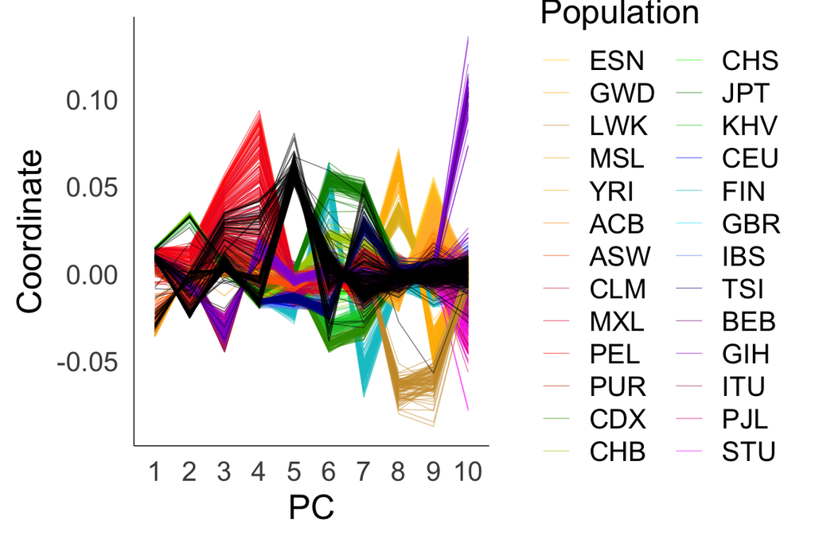

```r
pca.10.pcs <- pca$eigenvect[,1:10]
colnames(pca.10.pcs) <- as.character(1:10)

pca.10.pcs.1kg <- cbind(pca$sample.id, as.data.frame(pca.10.pcs)) %>%
  as.data.frame(stringsAsFactors=F) %>%
  dplyr::select(Sample.ID=1, everything()) %>%
  merge(., populations, by.x="Sample.ID", by.y="Sample.name") %>%
  merge(population.colors, ., by.x="Population", by.y="Population.code") %>%
  dplyr::mutate(Consortium = "1000 Genomes") %>%
  dplyr::mutate(Population = factor(Population, levels=population.colors$Population)) %>%
  dplyr::select(Sample.ID, Population, one_of(as.character(1:10))) %>%
  tidyr::gather("PC", "Coordinate", -Sample.ID, -Population) %>%
  dplyr::mutate(PC=factor(PC, levels=as.character(1:10)))

pca.10.pcs.motrpac <- cbind(pca$sample.id, as.data.frame(pca.10.pcs)) %>%
  as.data.frame(stringsAsFactors=F) %>%
  dplyr::select(Sample.ID=1, everything()) %>%
  dplyr::filter(!(Sample.ID %in% populations$Sample.name)) %>%
  tidyr::gather("PC", "Coordinate", -Sample.ID) %>%
  dplyr::mutate(PC=factor(PC, levels=as.character(1:10)))

ggplot() +
  geom_line(data=pca.10.pcs.1kg, aes(x=PC, y=Coordinate, group=Sample.ID, color=Population), alpha=0.5, size=0.25) +
  geom_line(data=pca.10.pcs.motrpac, aes(x=PC, y=Coordinate, group=Sample.ID), alpha=0.5, size=0.25) +
  scale_color_manual(values=pca.colors) +
  ggplot.theme
```

## PC 5 Correlation

PC 5 fully separates MoTrPAC from the 1000 genomes project. What variants are associated with PC 5?

```r
chr <- read.gdsn(index.gdsn(gds, "snp.chromosome"))
pos <- read.gdsn(index.gdsn(gds, "snp.position"))
corr <- snpgdsPCACorr(pca, gds, eig.which=5)
```

```r
data.frame(
  Abs.Corr=abs(corr$snpcorr[1,]),
  Chr=factor(chr, as.character(1:22)),
  Chr.Type=ifelse(as.numeric(chr) %% 2 == 0, "Even", "Odd"),
  Position=pos
) %>%
  ggplot(aes(x=Position, y=Abs.Corr)) +
  geom_point(aes(color=Chr.Type), size=0.25, alpha=0.5) +
  facet_grid(. ~ Chr, scales="free_x", space="free_x") +
  scale_color_manual(values=c("Even"="royalblue1", "Odd"="royalblue4")) +
  xlab("Position") + ylab("|Correlation|") +
  guides(color="none") +
  ggplot.theme +
  theme(panel.spacing=unit(0, "mm"), axis.text.x=element_blank())
```

[output not shown]